# Support for QIIME in R

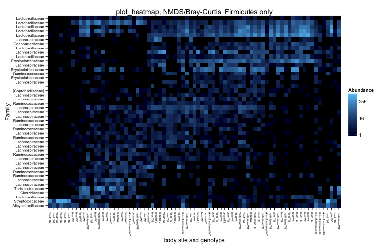

```r
openfpp.fir = subset_taxa(openfpp, Phylum == "Firmicutes")
title = "plot_heatmap, NMDS/Bray-Curtis, Firmicutes only"
p4 = plot_heatmap(openfpp.fir, "NMDS", "bray", taxa.label = "Family", sample.label = "bsgt",
    title = title)
p4$scales$scales[[1]]$name <- xlab
p4
```

Colorize axis labels? The ggplot2 package doesn't yet support an aesthetic mapping between a data variable and text color. Here is the added code for doing that (and results).

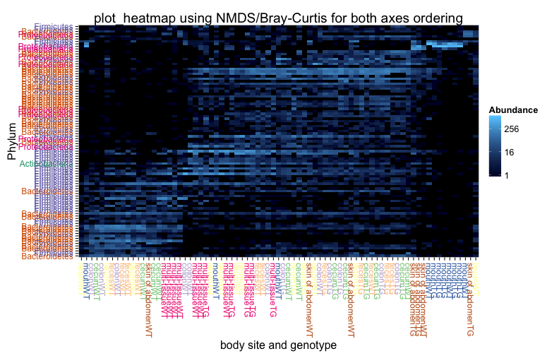

```r
# Full data
title = "plot_heatmap using NMDS/Bray-Curtis for both axes ordering"
p6 = plot_heatmap(openfpp, "NMDS", "bray", taxa.label = "Phylum", sample.label = "bsgt",
    title = title)
p6 = p6 + xlab("samples: body site and genotype")
gt = gsub("^([[:print:]]+)(WT|TG)$", "\\1", p6$scales$scales[[1]]$labels)
xfac = factor(gt)
p7 = p6 + theme(axis.text.x = element_text(colour = (scales::brewer_pal("qual",
    1))(nlevels(xfac))[xfac]))
yfac = factor(p6$scales$scales[[2]]$labels)
p7 = p7 + theme(axis.text.y = element_text(colour = (scales::brewer_pal("qual",
    2))(nlevels(yfac))[yfac]))
p7$scales$scales[[1]]$name <- xlab
p7 + theme(text = element_text(size = 16), axis.text.x = element_text(size = 12),
    axis.text.y = element_text(size = 12))
```

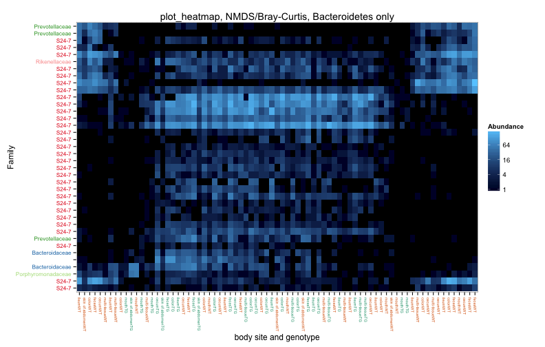

```r
# Bacteroidetes only
title = "plot_heatmap, NMDS/Bray-Curtis, Bacteroidetes only"
p6 = plot_heatmap(openfpp.bac, "NMDS", "bray", taxa.label = "Family", sample.label = "bsgt",
    title = title)
p6 = p6 + xlab("samples: body site and genotype")
gt = gsub("^([[:print:]]+)(WT|TG)$", "\\2", p6$scales$scales[[1]]$labels)
xfac = factor(gt)
p7 = p6 + theme(axis.text.x = element_text(colour = (scales::brewer_pal("qual",
    2))(nlevels(xfac))[xfac]))
yfac = factor(p6$scales$scales[[2]]$labels)
p7 = p7 + theme(axis.text.y = element_text(colour = (scales::brewer_pal("qual",
    3))(nlevels(yfac))[yfac]))
p7$scales$scales[[1]]$name <- xlab
p7
```

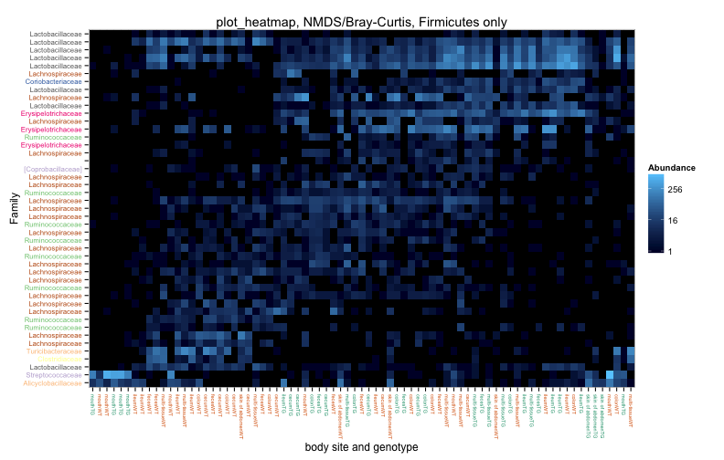

```r
# Firmicutes only
title = "plot_heatmap, NMDS/Bray-Curtis, Firmicutes only"
p6 = plot_heatmap(openfpp.fir, "NMDS", "bray", taxa.label = "Family", sample.label = "bsgt",
    title = title)
p6 = p6 + xlab("samples: body site and genotype")
gt = gsub("^([[:print:]]+)(WT|TG)$", "\\2", p6$scales$scales[[1]]$labels)
xfac = factor(gt)
p7 = p6 + theme(axis.text.x = element_text(colour = (scales::brewer_pal("qual",
    2))(nlevels(xfac))[xfac]))
yfac = factor(p6$scales$scales[[2]]$labels)
p7 = p7 + theme(axis.text.y = element_text(colour = rep((scales::brewer_pal("qual",
    1))(8), 2)[1:nlevels(yfac)][yfac]))
p7$scales$scales[[1]]$name <- xlab
p7
```

In case you're now wondering what the NMDS/Bray-Curtis plot now looks like on the `openfpp` filtered data.

```r
p5 = plot_ordination(openfpp, ordinate(openfpp, "NMDS", "bray"), color = "bodysite",
    shape = "GENOTYPE", title = "NMDS on Bray-Curtis distance of filtered open-reference data") +
    geom_point(size = 5)
```

```
## Square root transformation
## Wisconsin double standardization
## ... procrustes: rmse 0.03065  max resid 0.2384
## ... procrustes: rmse 0.001282  max resid 0.006649
## *** Solution reached
```

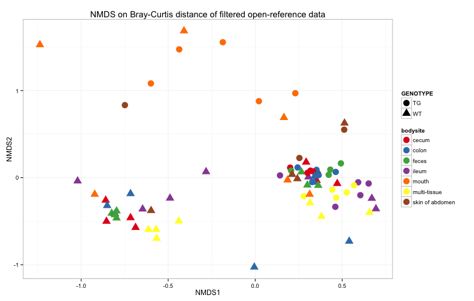

```r
p5
```

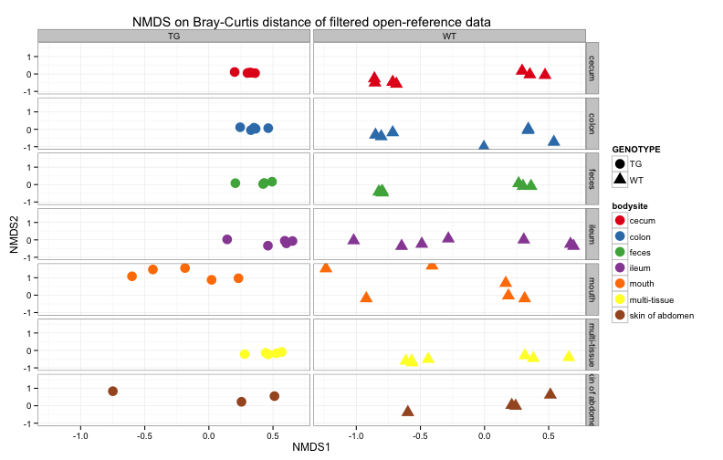

```r
p5 + facet_grid(bodysite ~ GENOTYPE)
```

### Network plot

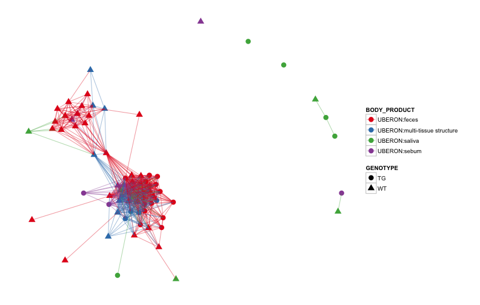

```r
openUUFnet = make_network(open, "samples", UniFrac[["unweighted"]][["open"]],
    max.dist = 0.6, keep.isolates = TRUE)
pnet = plot_network(openUUFnet, open, color = "BODY_PRODUCT", shape = "GENOTYPE",
    label = NULL)
pnet
```

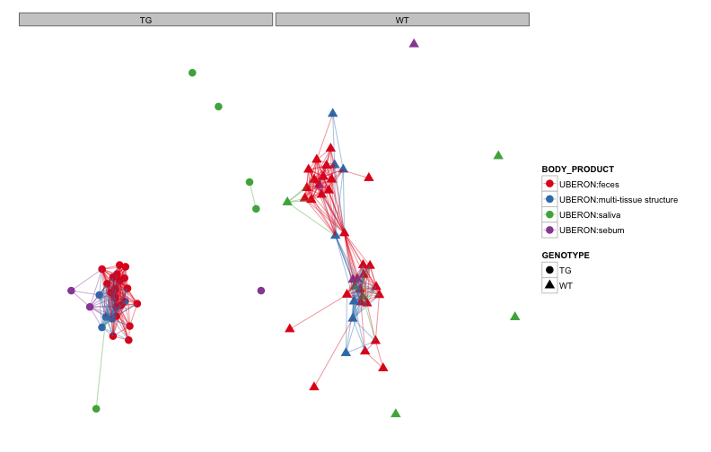

```r
pnet + facet_wrap(~GENOTYPE)
```

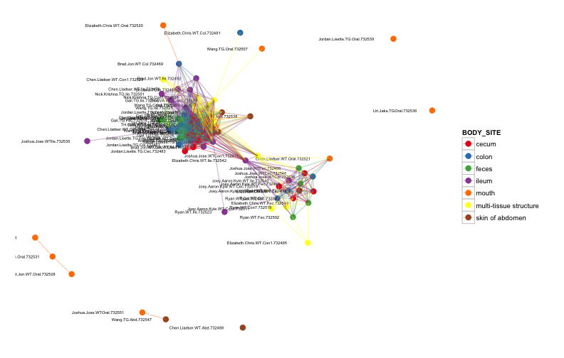

```r
plot_network(openUUFnet, open, color = "BODY_SITE")
```

```r
mtgt = mt(open, get_variable(open, "GENOTYPE"))
```

[output not shown]

```r
mtgt[which(mtgt$adjp < 0.05 & !is.na(mtgt$Phylum)), ]
```

```
##                     index teststat  rawp   adjp plower  Kingdom
## 308076               3852   -4.978 1e-04 0.0182 0.0001 Bacteria
## 212201                276   -4.525 1e-04 0.0182 0.0001 Bacteria
## New.ReferenceOTU61     97    4.261 1e-04 0.0182 0.0001 Bacteria
## 277624                586    4.231 1e-04 0.0182 0.0001 Bacteria
## 463794               2910    3.901 1e-04 0.0182 0.0001 Bacteria
## 175646                397    3.470 1e-04 0.0182 0.0001 Bacteria
## 826624               1472    3.113 1e-04 0.0182 0.0001 Bacteria
## 199118                 57   -4.369 2e-04 0.0365 0.0182 Bacteria
## 374370                319    4.102 2e-04 0.0365 0.0182 Bacteria
## 174056                433    3.897 2e-04 0.0365 0.0182 Bacteria
## 422931               2901    3.835 2e-04 0.0365 0.0182 Bacteria
## 207284                332    3.813 2e-04 0.0365 0.0182 Bacteria
## 278675                 35   -3.771 2e-04 0.0365 0.0182 Bacteria
## 197765               1570    3.767 2e-04 0.0365 0.0182 Bacteria
```

[output cut: 54 more lines]

It looks like the non-WT genotype never clusters with the WT that was on the left side of the UniFrac/MDS plot shown above.

# Save R image

Save the final R workspace to an `.RData` file for easy re-testing, modification of settings, etc.

```r
save.image("navasetal.RData")
```

# References

- Friedrich Leisch. Sweave: Dynamic generation of statistical reports using literate data analysis. In Wolfgang Härdle and Bernd Rönz, editors, Compstat 2002 - Proceedings in Computational Statistics, pages 575-580. Physica Verlag, Heidelberg, 2002. ISBN 3-7908-1517-9
- Yihui Xie (2013) Dynamic Documents with R and knitr. Chapman and Hall/CRC. ISBN 978-1482203530
- Yihui Xie (2013) knitr: A Comprehensive Tool for Reproducible Research in R. In Victoria Stodden, Friedrich Leisch and Roger D. Peng, editors, Implementing Reproducible Computational Research. Chapman and Hall/CRC. ISBN 978-1466561595
- JJ Allaire, Jeffrey Horner, Vicent Marti and Natacha Porte (2013). markdown: Markdown rendering for R. R package version 0.5.4. http://CRAN.R-project.org/package=markdown
- Robert Gentleman, et al. Bioconductor: open software development for computational biology and bioinformatics. Genome Biology, 2004. PMID: 15461798
- McMurdie PJ, Holmes S (2013) phyloseq: An R Package for Reproducible Interactive Analysis and Graphics of Microbiome Census Data. PLoS ONE 8(4): e61217. PMID: 23630581 doi:10.1371/journal.pone.0061217
- Hadley Wickham. ggplot2: Elegant Graphics for Data Analysis. v 6991, Use R! Springer, 2009 ISBN 0387981403, 9780387981406
- R Core Team. 2013 R: A Language and Environment for Statistical. Vienna, Austria. http://www.R-project.org

  ```
  @Manual{,
  title   = {R: A Language and Environment for Statistical
  Computing},
  author  = {{R Core Team}},
  organization = {R Foundation for Statistical Computing},
  address = {Vienna, Austria},
  year    = 2013,
  url= {http://www.R-project.org}
  }
  ```